# 3b_analyse_controls

Thomas E. Metherell

16/09/2021

This script analyses the cleaned data from Understanding Society dataset for use in our study of digital exclusion and adolescent mental health during the COVID-19 pandemic in the United Kingdom.

The focus of this analysis is fitting latent growth models to longitudinal SDQ data, divided by access to a computer and to a good internet connection and with covariates.

# Dependencies

We start by loading the necessary dependencies.

```r
library(tidyverse)
library(magrittr)
library(scales)
library(lavaan)
library(survey)
library(lavaan.survey)
library(visdat)
```

# Loading the data

We can now load the cleaned dataset (long and wide versions), and select the waves and variables that are relevant to this analysis.

```r
# Loading long dataset
data_full <- read.csv("Data/Cleaned/data.csv", quote = "")

# Loading wide dataset
data_wide <- read.csv("Data/Cleaned/data_wide.csv", quote = "")

# Selecting relevant variables and storing those in data_rel (long data)
data_rel <- data_full[data_full$wave == "W9" | data_full$wave == "CV4" | data_full$wave == "CV6" | data_full$wave == "CV8",] %>%
  dplyr::select(
    contains("ypsdqtd_dv"), # SDQ summary scores
    wave, # Wave
    pidp, # Participant ID
    ageon20200815, # Age on 15/08/2020
    sex_merged, # Sex
    birthy, # Birth year
    ethn_dv, # Ethnicity
    contains("ypschlth"), # Digital inclusion variables
    contains("betayth_lw") # Beta-version longitudinal weights
  )

# Selecting relevant variables and storing those in data_rel_wide (wide data)
data_rel_wide <- data_wide %>%
  dplyr::select(
    contains("ypsdqtd_dv"), # SDQ summary scores
    pidp, # Participant ID
    ageon20200815, # Age on 15/08/2020
    sex_merged, # Sex
    birthy, # Birth year
    ethn_dv, # Ethnicity
    mean_income, # Mean household income
    contains("ypschlth"), # Digital inclusion variables
    contains("betayth_lw"), # Beta-version longitudinal weights
  )

# Removing full datasets
rm(data_full)
rm(data_wide)
```

# Recoding variables

We redefine wave, sex and digital inclusion variables as factors in the long data.

```r
data_rel$wave <- factor(data_rel$wave, levels = c("W9", "CV4", "CV6", "CV8"))

data_rel$sex_merged <- factor(data_rel$sex_merged)
levels(data_rel$sex_merged) <- c("Male", "Female")

data_rel$ypschlth1 <- factor(data_rel$ypschlth1)
levels(data_rel$ypschlth1) <- c("No", "Yes")
data_rel$ypschlth2 <- factor(data_rel$ypschlth2)
levels(data_rel$ypschlth2) <- c("No", "Yes")
```

# Creating dataset for latent growth models

We specify the data frame `data_sdq`, which contains the data needed for fitting LGMs.

```r
# Creating dataset for LGM fitting
data_sdq <- data_rel_wide %>%
  dplyr::select(
    pidp, # Participant ID
    contains("ypsdqtd_dv"), # Total Difficulties score
    sex_merged, # Sex
    betayth_lw_CV8, # CV8 longitudinal weight
    ypschlth1, # Access to a computer
    ypschlth2, # Access to a good internet connection
    ethn_dv, # Ethnicity
    birthy, # Birth year
    mean_income # Mean household income
  )

# Excluding participants with no CV8 longitudinal weight
data_sdq <- data_sdq[!is.na(data_sdq$betayth_lw_CV8),]

# Renaming SDQ variables to the wave identifiers
names(data_sdq) <- str_replace(names(data_sdq), "ypsdqtd_dv_", "")

# Coding ethnicity as a dichotomous variable ("white or not")
data_sdq %<>% mutate(
  ethn_caucasian = if_else(ethn_dv == (1 | 2 | 3 | 4), 1, 0)
)

# Rescaling birth year between 0 and 1
data_sdq$birthy <- rescale(data_sdq$birthy, to = c(0,1))

# Reducing high outlier income to the next-highest value
data_sdq[which.max(data_sdq$mean_income),]$mean_income <- data_sdq[which(data_sdq$mean_income == sort(data_sdq$mean_income, decreasing = TRUE)[2]),]$mean_income

# Rescaling mean income between 0 and 1
data_sdq$mean_income <- rescale(data_sdq$mean_income, to = c(0,1))

# Specifying survey weights
survey_design <- svydesign(~0, data = data_sdq, weights = data_sdq$betayth_lw_CV8)
```

# Visualising missing data

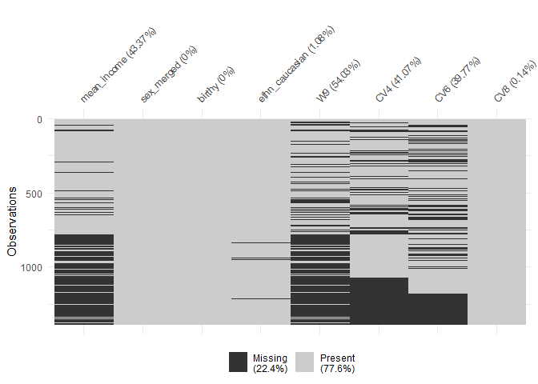

# Summarising SDQ scores by sociodemographic variables

We illustrate the mean SDQ scores across waves according to certain sociodemographic variables.

### Mean Total Difficulties scores by sex with standard error

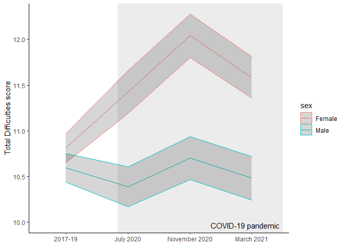

### Mean Total Difficulties scores by age with standard error

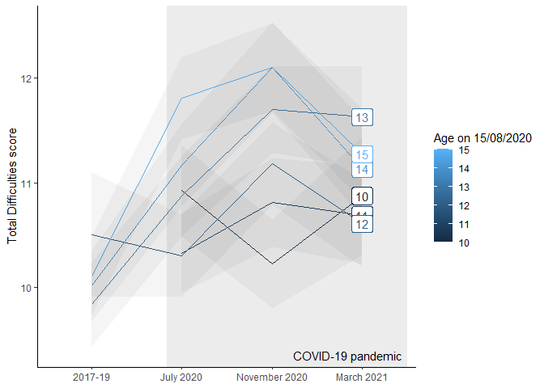

### Mean Total Difficulties scores by dichotomised ethnicity with standard error

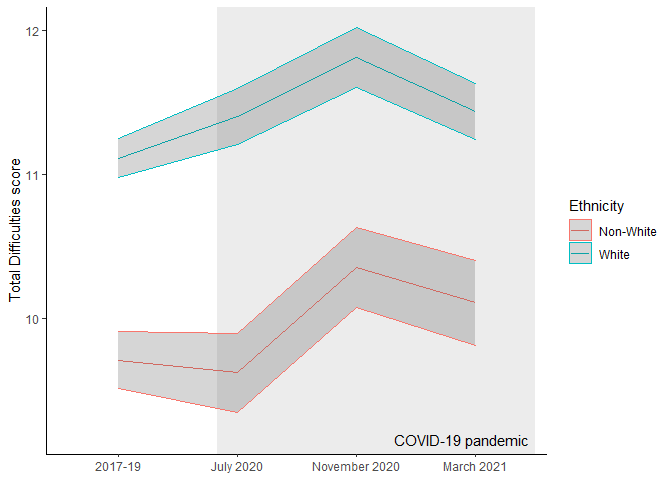

### Mean Total Difficulties scores by computer access with standard error

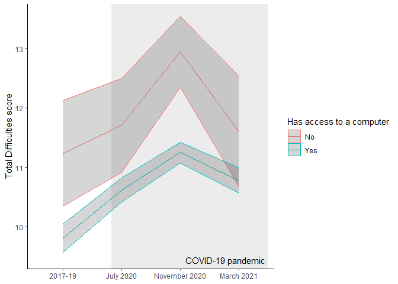

### Mean Total Difficulties scores by internet access with standard error

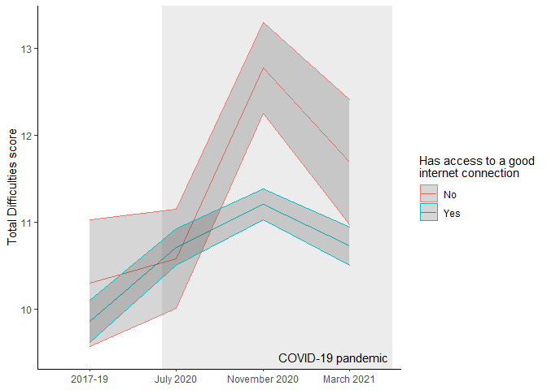

# Fitting models grouped by computer access with covariates

We now fit a new LGM with the participants grouped by whether or not they have access to a computer, and controlling for sex, birth year, ethnicity and mean household income.

```r
# Fitting no-change model
model_comp_nc <- '
sex_merged ~ 1; sex_merged ~~ sex_merged
birthy ~ 1; birthy ~~ birthy
ethn_caucasian ~ 1; ethn_caucasian ~~ ethn_caucasian
mean_income ~ 1; mean_income ~~ mean_income

i =~ 1*W9 + 1*CV4 + 1*CV6 + 1*CV8

i ~ sex_merged + birthy + ethn_caucasian + mean_income
'

fit_comp_nc <- growth(model_comp_nc, data = data_sdq[!is.na(data_sdq$ypschlth1),], group = "ypschlth1", missing = "fiml", estimator = "mlr")
# Fitting linear model
model_comp_lin <- '
sex_merged ~ 1; sex_merged ~~ sex_merged
birthy ~ 1; birthy ~~ birthy
ethn_caucasian ~ 1; ethn_caucasian ~~ ethn_caucasian
mean_income ~ 1; mean_income ~~ mean_income

i =~ 1*W9 + 1*CV4 + 1*CV6 + 1*CV8
s =~ 0*W9 + 1*CV4 + 2*CV6 + 3*CV8

i ~ sex_merged + birthy + ethn_caucasian + mean_income
s ~ sex_merged + birthy + ethn_caucasian + mean_income
'

fit_comp_lin <- growth(model_comp_lin, data = data_sdq[!is.na(data_sdq$ypschlth1),], group = "ypschlth1", missing = "fiml", estimator = "mlr")
# Comparing linear to no-change model
anova(fit_comp_lin, fit_comp_nc)
```

```
## Scaled Chi-Squared Difference Test (method = "satorra.bentler.2001")
##
## lavaan NOTE:
##     The "Chisq" column contains standard test statistics, not the
##     robust test that should be reported per model. A robust difference
##     test is a function of two standard (not robust) statistics.
##
##              Df   AIC   BIC   Chisq Chisq diff Df diff Pr(>Chisq)
## fit_comp_lin 38 17650 17886  91.205
## fit_comp_nc  52 17744 17915 213.534     117.86      14  < 2.2e-16 ***
## ---
## Signif. codes:  0 '***' 0.001 '**' 0.01 '*' 0.05 '.' 0.1 ' ' 1
```

```r
# Accepting linear over no-change model

# Fitting quadratic model
model_comp_quad <- '
sex_merged ~ 1; sex_merged ~~ sex_merged
birthy ~ 1; birthy ~~ birthy
ethn_caucasian ~ 1; ethn_caucasian ~~ ethn_caucasian
mean_income ~ 1; mean_income ~~ mean_income

i =~ 1*W9 + 1*CV4 + 1*CV6 + 1*CV8
s =~ 0*W9 + 1*CV4 + 2*CV6 + 3*CV8
q =~ 0*W9 + 1*CV4 + 4*CV6 + 9*CV8

i ~ sex_merged + birthy + ethn_caucasian + mean_income
s ~ sex_merged + birthy + ethn_caucasian + mean_income
q ~ sex_merged + birthy + ethn_caucasian + mean_income
'

fit_comp_quad <- growth(model_comp_quad, data = data_sdq[!is.na(data_sdq$ypschlth1),], group = "ypschlth1", missing = "fiml", estimator = "mlr")
# Comparing quadratic to linear model
anova(fit_comp_quad, fit_comp_lin)
```

```
## Scaled Chi-Squared Difference Test (method = "satorra.bentler.2001")
##
## lavaan NOTE:
##     The "Chisq" column contains standard test statistics, not the
##     robust test that should be reported per model. A robust difference
##     test is a function of two standard (not robust) statistics.
##
##               Df   AIC   BIC  Chisq Chisq diff Df diff Pr(>Chisq)
## fit_comp_quad 22 17618 17930 27.217
## fit_comp_lin  38 17650 17886 91.205     58.227      16  1.038e-06 ***
## ---
## Signif. codes:  0 '***' 0.001 '**' 0.01 '*' 0.05 '.' 0.1 ' ' 1
```

```r
# Accepting quadratic over linear model

# Fitting model with error variances constrained to equality
model_comp_con_ervar <- '
sex_merged ~ 1; sex_merged ~~ sex_merged
birthy ~ 1; birthy ~~ birthy
ethn_caucasian ~ 1; ethn_caucasian ~~ ethn_caucasian
mean_income ~ 1; mean_income ~~ mean_income

i =~ 1*W9 + 1*CV4 + 1*CV6 + 1*CV8
s =~ 0*W9 + 1*CV4 + 2*CV6 + 3*CV8
q =~ 0*W9 + 1*CV4 + 4*CV6 + 9*CV8

W9 ~~ c(ervar1, ervar1) * W9
CV4 ~~ c(ervar2, ervar2) * CV4
CV6 ~~ c(ervar3, ervar3) * CV6
CV8 ~~ c(ervar4, ervar4) * CV8

i ~ sex_merged + birthy + ethn_caucasian + mean_income
s ~ sex_merged + birthy + ethn_caucasian + mean_income
q ~ sex_merged + birthy + ethn_caucasian + mean_income
'

fit_comp_con_ervar <- growth(model_comp_con_ervar, data = data_sdq[!is.na(data_sdq$ypschlth1),], group = "ypschlth1", missing = "fiml", estimator = "mlr")
# Comparing model with constrained error variances to free model
anova(fit_comp_con_ervar, fit_comp_quad)
```

```
## Scaled Chi-Squared Difference Test (method = "satorra.bentler.2001")
##
## lavaan NOTE:
##     The "Chisq" column contains standard test statistics, not the
##     robust test that should be reported per model. A robust difference
##     test is a function of two standard (not robust) statistics.
##
##                    Df   AIC   BIC  Chisq Chisq diff Df diff Pr(>Chisq)
## fit_comp_quad      22 17618 17930 27.217
## fit_comp_con_ervar 26 17613 17906 30.282     2.7817       4      0.595
```

```r
# Accepting model with constrained error variances over model without

# Fitting model with constrained y-intercept
model_comp_con_ervar_i <- '
sex_merged ~ 1; sex_merged ~~ sex_merged
birthy ~ 1; birthy ~~ birthy
ethn_caucasian ~ 1; ethn_caucasian ~~ ethn_caucasian
mean_income ~ 1; mean_income ~~ mean_income

i =~ 1*W9 + 1*CV4 + 1*CV6 + 1*CV8
s =~ 0*W9 + 1*CV4 + 2*CV6 + 3*CV8
q =~ 0*W9 + 1*CV4 + 4*CV6 + 9*CV8

W9 ~~ c(ervar1, ervar1) * W9
CV4 ~~ c(ervar2, ervar2) * CV4
CV6 ~~ c(ervar3, ervar3) * CV6
CV8 ~~ c(ervar4, ervar4) * CV8

i ~ c(i_1, i_1) * 1

i ~ sex_merged + birthy + ethn_caucasian + mean_income
s ~ sex_merged + birthy + ethn_caucasian + mean_income
q ~ sex_merged + birthy + ethn_caucasian + mean_income
'

fit_comp_con_ervar_i <- growth(model_comp_con_ervar_i, data = data_sdq[!is.na(data_sdq$ypschlth1),], group = "ypschlth1", missing = "fiml", estimator = "mlr")
# Comparing model with constrained y-intercept to free model
anova(fit_comp_con_ervar_i, fit_comp_con_ervar)
```

```
## Scaled Chi-Squared Difference Test (method = "satorra.bentler.2001")
##
## lavaan NOTE:
##     The "Chisq" column contains standard test statistics, not the
##     robust test that should be reported per model. A robust difference
##     test is a function of two standard (not robust) statistics.
##
##                      Df   AIC   BIC  Chisq Chisq diff Df diff Pr(>Chisq)
## fit_comp_con_ervar   26 17613 17906 30.282
## fit_comp_con_ervar_i 27 17612 17900 30.767    0.36611       1     0.5451
```

```r
# Accepting model with constrained y-intercept over free model

# Fitting model with constrained linear coefficient
model_comp_con_ervar_i_s <- '
sex_merged ~ 1; sex_merged ~~ sex_merged
birthy ~ 1; birthy ~~ birthy
ethn_caucasian ~ 1; ethn_caucasian ~~ ethn_caucasian
mean_income ~ 1; mean_income ~~ mean_income

i =~ 1*W9 + 1*CV4 + 1*CV6 + 1*CV8
s =~ 0*W9 + 1*CV4 + 2*CV6 + 3*CV8
q =~ 0*W9 + 1*CV4 + 4*CV6 + 9*CV8

W9 ~~ c(ervar1, ervar1) * W9
CV4 ~~ c(ervar2, ervar2) * CV4
CV6 ~~ c(ervar3, ervar3) * CV6
CV8 ~~ c(ervar4, ervar4) * CV8

i ~ c(i_1, i_1) * 1
s ~ c(s_1, s_1) * 1

i ~ sex_merged + birthy + ethn_caucasian + mean_income
s ~ sex_merged + birthy + ethn_caucasian + mean_income
q ~ sex_merged + birthy + ethn_caucasian + mean_income
'

fit_comp_con_ervar_i_s <- growth(model_comp_con_ervar_i_s, data = data_sdq[!is.na(data_sdq$ypschlth1),], group = "ypschlth1", missing = "fiml", estimator = "mlr")
# Comparing model with constrained linear coefficient to model without
anova(fit_comp_con_ervar_i_s, fit_comp_con_ervar_i)
```

```
## Scaled Chi-Squared Difference Test (method = "satorra.bentler.2001")
##
## lavaan NOTE:
##     The "Chisq" column contains standard test statistics, not the
##     robust test that should be reported per model. A robust difference
##     test is a function of two standard (not robust) statistics.
##
##                        Df   AIC   BIC  Chisq Chisq diff Df diff Pr(>Chisq)
## fit_comp_con_ervar_i   27 17612 17900 30.767
## fit_comp_con_ervar_i_s 28 17620 17904 41.513     11.428       1  0.0007234 ***
## ---
## Signif. codes:  0 '***' 0.001 '**' 0.01 '*' 0.05 '.' 0.1 ' ' 1
```

```r
# Rejecting model with constrained linear coefficient

# Fitting model with constrained quadratic coefficient
model_comp_con_ervar_i_q <- '
sex_merged ~ 1; sex_merged ~~ sex_merged
birthy ~ 1; birthy ~~ birthy
ethn_caucasian ~ 1; ethn_caucasian ~~ ethn_caucasian
mean_income ~ 1; mean_income ~~ mean_income

i =~ 1*W9 + 1*CV4 + 1*CV6 + 1*CV8
s =~ 0*W9 + 1*CV4 + 2*CV6 + 3*CV8
q =~ 0*W9 + 1*CV4 + 4*CV6 + 9*CV8

W9 ~~ c(ervar1, ervar1) * W9
CV4 ~~ c(ervar2, ervar2) * CV4
CV6 ~~ c(ervar3, ervar3) * CV6
CV8 ~~ c(ervar4, ervar4) * CV8

i ~ c(i_1, i_1) * 1
q ~ c(q_1, q_1) * 1

i ~ sex_merged + birthy + ethn_caucasian + mean_income
s ~ sex_merged + birthy + ethn_caucasian + mean_income
q ~ sex_merged + birthy + ethn_caucasian + mean_income
'

fit_comp_con_ervar_i_q <- growth(model_comp_con_ervar_i_q, data = data_sdq[!is.na(data_sdq$ypschlth1),], group = "ypschlth1", missing = "fiml", estimator = "mlr")
# Comparing model with constrained quadratic coefficient to model without
anova(fit_comp_con_ervar_i_q, fit_comp_con_ervar_i)
```

```
## Scaled Chi-Squared Difference Test (method = "satorra.bentler.2001")
##
## lavaan NOTE:
##     The "Chisq" column contains standard test statistics, not the
##     robust test that should be reported per model. A robust difference
##     test is a function of two standard (not robust) statistics.
##
##                        Df   AIC   BIC  Chisq Chisq diff Df diff Pr(>Chisq)
## fit_comp_con_ervar_i   27 17612 17900 30.767
## fit_comp_con_ervar_i_q 28 17621 17905 42.659     8.4992       1   0.003553 **
## ---
## Signif. codes:  0 '***' 0.001 '**' 0.01 '*' 0.05 '.' 0.1 ' ' 1
```

```r
# Rejecting model with constrained quadratic coefficient
fit_comp_prov <- fit_comp_con_ervar_i

# Fitting model with constrained y-intercept variance
model_comp_con_ivar <- '
sex_merged ~ 1; sex_merged ~~ sex_merged
birthy ~ 1; birthy ~~ birthy
ethn_caucasian ~ 1; ethn_caucasian ~~ ethn_caucasian
mean_income ~ 1; mean_income ~~ mean_income

i =~ 1*W9 + 1*CV4 + 1*CV6 + 1*CV8
s =~ 0*W9 + 1*CV4 + 2*CV6 + 3*CV8
q =~ 0*W9 + 1*CV4 + 4*CV6 + 9*CV8

W9 ~~ c(ervar1, ervar1) * W9
CV4 ~~ c(ervar2, ervar2) * CV4
CV6 ~~ c(ervar3, ervar3) * CV6
CV8 ~~ c(ervar4, ervar4) * CV8

i ~ c(i_1, i_1) * 1

i ~~ c(ivar, ivar) * i

i ~ sex_merged + birthy + ethn_caucasian + mean_income
s ~ sex_merged + birthy + ethn_caucasian + mean_income
q ~ sex_merged + birthy + ethn_caucasian + mean_income
'

fit_comp_con_ivar <- growth(model_comp_con_ivar, data = data_sdq[!is.na(data_sdq$ypschlth1),], group = "ypschlth1", missing = "fiml", estimator = "mlr")
# Comparing model with constrained y-intercept variance to model without
anova(fit_comp_con_ivar, fit_comp_prov)
```

```
## Scaled Chi-Squared Difference Test (method = "satorra.bentler.2001")
##
## lavaan NOTE:
##     The "Chisq" column contains standard test statistics, not the
##     robust test that should be reported per model. A robust difference
##     test is a function of two standard (not robust) statistics.
##
##                   Df   AIC   BIC  Chisq Chisq diff Df diff Pr(>Chisq)
## fit_comp_prov     27 17612 17900 30.767
## fit_comp_con_ivar 28 17610 17893 30.867    0.13419       1     0.7141
```

```r
# Accepting model with constrained y-intercept variance over model without

# Fitting model with constrained linear coefficient variance
model_comp_con_ivar_svar <- '
sex_merged ~ 1; sex_merged ~~ sex_merged
birthy ~ 1; birthy ~~ birthy
ethn_caucasian ~ 1; ethn_caucasian ~~ ethn_caucasian
mean_income ~ 1; mean_income ~~ mean_income

i =~ 1*W9 + 1*CV4 + 1*CV6 + 1*CV8
s =~ 0*W9 + 1*CV4 + 2*CV6 + 3*CV8
q =~ 0*W9 + 1*CV4 + 4*CV6 + 9*CV8

W9 ~~ c(ervar1, ervar1) * W9
CV4 ~~ c(ervar2, ervar2) * CV4
CV6 ~~ c(ervar3, ervar3) * CV6
CV8 ~~ c(ervar4, ervar4) * CV8

i ~ c(i_1, i_1) * 1

i ~~ c(ivar, ivar) * i
s ~~ c(svar, svar) * s

i ~ sex_merged + birthy + ethn_caucasian + mean_income
s ~ sex_merged + birthy + ethn_caucasian + mean_income
q ~ sex_merged + birthy + ethn_caucasian + mean_income
'

fit_comp_con_ivar_svar <- growth(model_comp_con_ivar_svar, data = data_sdq[!is.na(data_sdq$ypschlth1),], group = "ypschlth1", missing = "fiml", estimator = "mlr")
# Comparing model with constrained linear coefficient variance to model without
anova(fit_comp_con_ivar_svar, fit_comp_con_ivar)
```

```
## Scaled Chi-Squared Difference Test (method = "satorra.bentler.2001")
##
## lavaan NOTE:
##     The "Chisq" column contains standard test statistics, not the
##     robust test that should be reported per model. A robust difference
##     test is a function of two standard (not robust) statistics.
##
##                        Df   AIC   BIC  Chisq Chisq diff Df diff Pr(>Chisq)
## fit_comp_con_ivar      28 17610 17893 30.867
## fit_comp_con_ivar_svar 29 17609 17888 32.034     0.7952       1     0.3725
```

```r
# Accepting model with constrained linear coefficient variance over model without

# Fitting model with constrained quadratic coefficient variance
model_comp_con_ivar_svar_qvar <- '
sex_merged ~ 1; sex_merged ~~ sex_merged
birthy ~ 1; birthy ~~ birthy
ethn_caucasian ~ 1; ethn_caucasian ~~ ethn_caucasian
mean_income ~ 1; mean_income ~~ mean_income

i =~ 1*W9 + 1*CV4 + 1*CV6 + 1*CV8
s =~ 0*W9 + 1*CV4 + 2*CV6 + 3*CV8
q =~ 0*W9 + 1*CV4 + 4*CV6 + 9*CV8

W9 ~~ c(ervar1, ervar1) * W9
CV4 ~~ c(ervar2, ervar2) * CV4
CV6 ~~ c(ervar3, ervar3) * CV6
CV8 ~~ c(ervar4, ervar4) * CV8

i ~ c(i_1, i_1) * 1

i ~~ c(ivar, ivar) * i
s ~~ c(svar, svar) * s
q ~~ c(qvar, qvar) * q

i ~ sex_merged + birthy + ethn_caucasian + mean_income
s ~ sex_merged + birthy + ethn_caucasian + mean_income
q ~ sex_merged + birthy + ethn_caucasian + mean_income
'

fit_comp_con_ivar_svar_qvar <- growth(model_comp_con_ivar_svar_qvar, data = data_sdq[!is.na(data_sdq$ypschlth1),], group = "ypschlth1", missing = "fiml", estimator = "mlr")
# Comparing model with constrained quadratic coefficient variance to model without
anova(fit_comp_con_ivar_svar_qvar, fit_comp_con_ivar_svar)
```

```
## Scaled Chi-Squared Difference Test (method = "satorra.bentler.2001")
##
## lavaan NOTE:
##     The "Chisq" column contains standard test statistics, not the
##     robust test that should be reported per model. A robust difference
##     test is a function of two standard (not robust) statistics.
##
##                             Df   AIC   BIC  Chisq Chisq diff Df diff Pr(>Chisq)
## fit_comp_con_ivar_svar      29 17609 17888 32.034
## fit_comp_con_ivar_svar_qvar 30 17607 17882 32.575    0.56367       1     0.4528
```

```r
# Accepting model with constrained quadratic coefficient variance over model without
fit_comp_prov <- fit_comp_con_ivar_svar_qvar

# Fitting model with constrained y-intercept/linear coefficient covariance
model_comp_con_iscovar <- '
sex_merged ~ 1; sex_merged ~~ sex_merged
birthy ~ 1; birthy ~~ birthy
ethn_caucasian ~ 1; ethn_caucasian ~~ ethn_caucasian
mean_income ~ 1; mean_income ~~ mean_income

i =~ 1*W9 + 1*CV4 + 1*CV6 + 1*CV8
s =~ 0*W9 + 1*CV4 + 2*CV6 + 3*CV8
q =~ 0*W9 + 1*CV4 + 4*CV6 + 9*CV8

W9 ~~ c(ervar1, ervar1) * W9
CV4 ~~ c(ervar2, ervar2) * CV4
CV6 ~~ c(ervar3, ervar3) * CV6
CV8 ~~ c(ervar4, ervar4) * CV8

i ~ c(i_1, i_1) * 1

i ~~ c(ivar, ivar) * i
s ~~ c(svar, svar) * s
q ~~ c(qvar, qvar) * q

i ~~ c(iscovar, iscovar) * s

i ~ sex_merged + birthy + ethn_caucasian + mean_income
s ~ sex_merged + birthy + ethn_caucasian + mean_income
q ~ sex_merged + birthy + ethn_caucasian + mean_income
'

fit_comp_con_iscovar <- growth(model_comp_con_iscovar, data = data_sdq[!is.na(data_sdq$ypschlth1),], group = "ypschlth1", missing = "fiml", estimator = "mlr")
# Comparing model with constrained y-intercept/linear coefficient covariance to model without
anova(fit_comp_con_iscovar, fit_comp_prov)
```

```
## Scaled Chi-Squared Difference Test (method = "satorra.bentler.2001")
##
## lavaan NOTE:
##     The "Chisq" column contains standard test statistics, not the
##     robust test that should be reported per model. A robust difference
##     test is a function of two standard (not robust) statistics.
##
##                      Df   AIC   BIC  Chisq Chisq diff Df diff Pr(>Chisq)
## fit_comp_prov        30 17607 17882 32.575
## fit_comp_con_iscovar 31 17606 17876 33.489    0.67745       1     0.4105
```

```r
# Accepting model with constrained y-intercept/linear coefficient covariance over model without

# Fitting model with constrained y-intercept/quadratic coefficient covariance
model_comp_con_iscovar_iqcovar <- '
sex_merged ~ 1; sex_merged ~~ sex_merged
birthy ~ 1; birthy ~~ birthy
ethn_caucasian ~ 1; ethn_caucasian ~~ ethn_caucasian
mean_income ~ 1; mean_income ~~ mean_income

i =~ 1*W9 + 1*CV4 + 1*CV6 + 1*CV8
s =~ 0*W9 + 1*CV4 + 2*CV6 + 3*CV8
q =~ 0*W9 + 1*CV4 + 4*CV6 + 9*CV8

W9 ~~ c(ervar1, ervar1) * W9
CV4 ~~ c(ervar2, ervar2) * CV4
CV6 ~~ c(ervar3, ervar3) * CV6
CV8 ~~ c(ervar4, ervar4) * CV8

i ~ c(i_1, i_1) * 1

i ~~ c(ivar, ivar) * i
s ~~ c(svar, svar) * s
q ~~ c(qvar, qvar) * q

i ~~ c(iscovar, iscovar) * s
i ~~ c(iqcovar, iqcovar) * q

i ~ sex_merged + birthy + ethn_caucasian + mean_income
s ~ sex_merged + birthy + ethn_caucasian + mean_income
q ~ sex_merged + birthy + ethn_caucasian + mean_income
'

fit_comp_con_iscovar_iqcovar <- growth(model_comp_con_iscovar_iqcovar, data = data_sdq[!is.na(data_sdq$ypschlth1),], group = "ypschlth1", missing = "fiml", estimator = "mlr")
# Comparing model with constrained y-intercept/quadratic coefficient covariance to model without
anova(fit_comp_con_iscovar_iqcovar, fit_comp_con_iscovar)
```

```
## Scaled Chi-Squared Difference Test (method = "satorra.bentler.2001")
##
## lavaan NOTE:
##     The "Chisq" column contains standard test statistics, not the
##     robust test that should be reported per model. A robust difference
##     test is a function of two standard (not robust) statistics.
##
##                              Df   AIC   BIC  Chisq Chisq diff Df diff
## fit_comp_con_iscovar         31 17606 17876 33.489
## fit_comp_con_iscovar_iqcovar 32 17604 17869 33.609    0.13296       1
##                              Pr(>Chisq)
## fit_comp_con_iscovar
## fit_comp_con_iscovar_iqcovar     0.7154
```

```r
# Accepting model with constrained y-intercept/quadratic coefficient covariance over model without

# Fitting model with constrained linear coefficient/quadratic coefficient covariance
model_comp_con_iscovar_iqcovar_sqcovar <- '
sex_merged ~ 1; sex_merged ~~ sex_merged
birthy ~ 1; birthy ~~ birthy
ethn_caucasian ~ 1; ethn_caucasian ~~ ethn_caucasian
mean_income ~ 1; mean_income ~~ mean_income

i =~ 1*W9 + 1*CV4 + 1*CV6 + 1*CV8
s =~ 0*W9 + 1*CV4 + 2*CV6 + 3*CV8
q =~ 0*W9 + 1*CV4 + 4*CV6 + 9*CV8

i ~ c(i_1, i_1) * 1

W9 ~~ c(ervar1, ervar1) * W9
CV4 ~~ c(ervar2, ervar2) * CV4
CV6 ~~ c(ervar3, ervar3) * CV6
CV8 ~~ c(ervar4, ervar4) * CV8

i ~~ c(ivar, ivar) * i
s ~~ c(svar, svar) * s
q ~~ c(qvar, qvar) * q

i ~~ c(iscovar, iscovar) * s
i ~~ c(iqcovar, iqcovar) * q
s ~~ c(sqcovar, sqcovar) * q

i ~ sex_merged + birthy + ethn_caucasian + mean_income
s ~ sex_merged + birthy + ethn_caucasian + mean_income
q ~ sex_merged + birthy + ethn_caucasian + mean_income
'

fit_comp_con_iscovar_iqcovar_sqcovar <- growth(model_comp_con_iscovar_iqcovar_sqcovar, data = data_sdq[!is.na(data_sdq$ypschlth1),], group = "ypschlth1", missing = "fiml", estimator = "mlr")
# Comparing model with constrained linear coefficient/quadratic coefficient covariance to model without
anova(fit_comp_con_iscovar_iqcovar_sqcovar, fit_comp_con_iscovar_iqcovar, method = "satorra.bentler.2010")
```

```
## Scaled Chi-Squared Difference Test (method = "satorra.bentler.2010")
##
## lavaan NOTE:
##     The "Chisq" column contains standard test statistics, not the
##     robust test that should be reported per model. A robust difference
##     test is a function of two standard (not robust) statistics.
##
##                                      Df   AIC   BIC  Chisq Chisq diff Df diff
## fit_comp_con_iscovar_iqcovar         32 17604 17869 33.609
## fit_comp_con_iscovar_iqcovar_sqcovar 33 17603 17864 34.717     1.1017       1
##                                      Pr(>Chisq)
## fit_comp_con_iscovar_iqcovar
## fit_comp_con_iscovar_iqcovar_sqcovar     0.2939
```

```r
# Accepting model with constrained linear coefficient/quadratic coefficient covariance over model without
fit_comp <- fit_comp_con_iscovar_iqcovar_sqcovar

# Summary of unweighted model
summary(fit_comp)
```

```
## lavaan 0.6-9 ended normally after 396 iterations
##
##   Estimator                                         ML
##   Optimization method                           NLMINB
##   Number of model parameters                        66
##   Number of equality constraints                    11
##
##   Number of observations per group:
##     1                                              785
##     0                                               51
##   Number of missing patterns per group:
##     1                                               13
##     0                                                7
##
## Model Test User Model:
##                                                Standard      Robust
##   Test Statistic                                 34.717      36.052
##   Degrees of freedom                                 33          33
##   P-value (Chi-square)                            0.386       0.328
##   Scaling correction factor                                   0.963
##        Yuan-Bentler correction (Mplus variant)
##   Test statistic for each group:
##     1                                           10.885      11.304
##     0                                           23.832      24.748
##
## Parameter Estimates:
##
##   Standard errors                             Sandwich
##   Information bread                           Observed
##   Observed information based on                Hessian
##
##
## Group 1 [1]:
##
## Latent Variables:
##                    Estimate  Std.Err  z-value  P(>|z|)
##   i =~
##     W9                1.000
##     CV4               1.000
##     CV6               1.000
```

[output cut: 125 more lines]

```
##    .q                -3.197    1.126   -2.839    0.005
##
## Variances:
##                    Estimate  Std.Err  z-value  P(>|z|)
##     sx_mrgd           0.208    0.026    7.902    0.000
##     birthy            0.072    0.011    6.399    0.000
##     ethn_cc           0.250    0.003   85.525    0.000
##     men_ncm           0.031    0.014    2.290    0.022
##    .W9      (erv1)    8.583    4.050    2.119    0.034
##    .CV4     (erv2)   10.214    1.353    7.551    0.000
##    .CV6     (erv3)    8.266    1.351    6.118    0.000
##    .CV8     (erv4)    4.855    3.786    1.282    0.200
##    .i       (ivar)   21.459    4.394    4.883    0.000
##    .s       (svar)    8.969    5.252    1.708    0.088
##    .q       (qvar)    0.377    0.348    1.084    0.278
```

```r
# Saving model fit object
saveRDS(fit_comp, file = "Data/Objects/comp_cov.rds")

# Preparing unweighted LGM functions for plotting
pT <- parTable(fit_comp)
pT %<>% mutate(maxv = est + se, minv = est - se)
fit_comp_fn0 <- function(x) pT[pT$lhs == "i" & pT$op == "~1" & pT$group == 2,]$est + pT[pT$lhs == "s" & pT$op == "~1" & pT$group == 2,]$est*x + pT[pT$lhs == "q" & pT$op == "~1" & pT$group == 2,]$est*x^2
fit_comp_fn1 <- function(x) pT[pT$lhs == "i" & pT$op == "~1" & pT$group == 1,]$est + pT[pT$lhs == "s" & pT$op == "~1" & pT$group == 1,]$est*x + pT[pT$lhs == "q" & pT$op == "~1" & pT$group == 1,]$est*x^2

# Using LGM parameters to predict individual trajectories
indiv_traj_p <- predict(fit_comp)

# Saving predicted trajectories object
saveRDS(indiv_traj_p, file = "Data/Objects/comp_predict.rds")

# Extracting predicted individual trajectory data
indiv_traj0 <- data.frame(indiv_traj_p[["0"]])
indiv_traj1 <- data.frame(indiv_traj_p[["1"]])
i <- nrow(indiv_traj0)
j <- nrow(indiv_traj1)

# Using predicted individual trajectories to indicate the clinical significance of the results. The maximum modelled Total Difficulties score is identified for each participant and this maximum value compared against the standard SDQ clinical cutoffs (the ranges have been adjusted to fit a continuous scale)

indiv_traj0 <- indiv_traj0 %>% rowwise() %>% mutate(max_value = case_when(
  0 <= -s/(2*q) & -s/(2*q) <= 3 ~ max(i, i - s^2/(4*q), i + 3*s + 9*q),
  -s/(2*q) < 0 | -s/(2*q) > 3 ~ max(i, i + 3*s + 9*q)
))
cat(paste("Total number without computer access =", nrow(indiv_traj0), "\n\n"))
```

```
## Total number without computer access = 51
```

```r
cat(paste("Number of individuals predicted to have at worst slightly raised Total Difficulties (no computer access) =", nrow(indiv_traj0[indiv_traj0$max_value >= 14.5 & indiv_traj0$max_value < 17.5,]), "\n\n"))
```

```
## Number of individuals predicted to have at worst slightly raised Total Difficulties (no computer access) = 8
```

```r
cat(paste("Number of individuals predicted to have at worst high Total Difficulties (no computer access) =", nrow(indiv_traj0[indiv_traj0$max_value >= 17.5 & indiv_traj0$max_value < 19.5,]), "\n\n"))
```

```
## Number of individuals predicted to have at worst high Total Difficulties (no computer access) = 4
```

```r
cat(paste("Number of individuals predicted to have at worst very high Total Difficulties (no computer access) =", nrow(indiv_traj0[indiv_traj0$max_value >= 19.5,]), "\n\n"))
```

```
## Number of individuals predicted to have at worst very high Total Difficulties (no computer access) = 8
```

```r
indiv_traj1 <- indiv_traj1 %>% rowwise() %>% mutate(max_value = case_when(
  0 <= -s/(2*q) & -s/(2*q) <= 3 ~ max(i, i - s^2/(4*q), i + 3*s + 9*q),
  -s/(2*q) < 0 | -s/(2*q) > 3 ~ max(i, i + 3*s + 9*q)
))
cat(paste("Total number with computer access =", nrow(indiv_traj1)))
```

```
## Total number with computer access = 785
```

```r
cat(paste("Number of individuals predicted to have at worst slightly raised Total Difficulties (with computer access) =", nrow(indiv_traj1[indiv_traj1$max_value >= 14.5 & indiv_traj1$max_value < 17.5,]), "\n\n"))
```

```
## Number of individuals predicted to have at worst slightly raised Total Difficulties (with computer access) = 103
```

```r
cat(paste("Number of individuals predicted to have at worst high Total Difficulties (with computer access) =", nrow(indiv_traj1[indiv_traj1$max_value >= 17.5 & indiv_traj1$max_value < 19.5,]), "\n\n"))
```

```
## Number of individuals predicted to have at worst high Total Difficulties (with computer access) = 47
```

```r
cat(paste("Number of individuals predicted to have at worst very high Total Difficulties (with computer access) =", nrow(indiv_traj1[indiv_traj1$max_value >= 19.5,]), "\n\n"))
```

```
## Number of individuals predicted to have at worst very high Total Difficulties (with computer access) = 63
```

### Final LGM (unweighted)

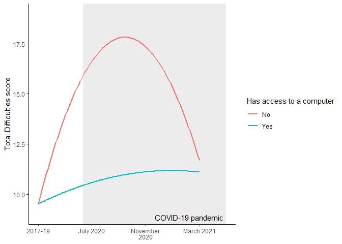

### Final LGM (unweighted, by group with predicted individual trajectories)

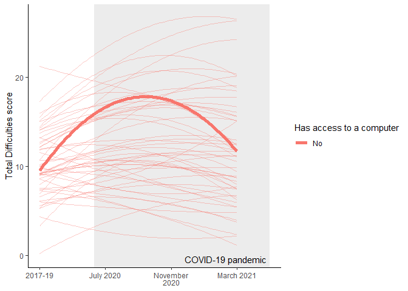

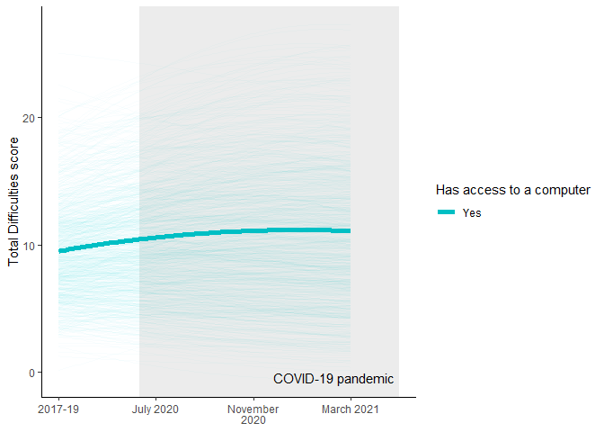

```r
# Applying weights to model
fit_comp_weighted <- lavaan.survey(fit_comp_con_iscovar_iqcovar_sqcovar, survey_design, estimator = "ML")
# Summary of weighted model
summary(fit_comp_weighted)
```

```
## lavaan 0.6-9 ended normally after 349 iterations
##
##   Estimator                                         ML
##   Optimization method                           NLMINB
##   Number of model parameters                        66
##   Number of equality constraints                    11
##
##   Number of observations per group:
##     Group 1                                        785
##     Group 2                                         51
##
## Model Test User Model:
##
##   Test statistic                               203.267
##   Degrees of freedom                                33
##   P-value (Chi-square)                           0.000
##   Test statistic for each group:
##     Group 1                                     64.012
##     Group 2                                    139.255
##
## Parameter Estimates:
##
##   Standard errors                             Standard
##   Information                                 Observed
##   Observed information based on                Hessian
##
##
## Group 1 [Group 1]:
##
## Latent Variables:
##                    Estimate  Std.Err  z-value  P(>|z|)
##   i =~
##     W9                1.000
##     CV4               1.000
##     CV6               1.000
##     CV8               1.000
##   s =~
##     W9                0.000
##     CV4               1.000
##     CV6               2.000
```

[output cut: 120 more lines]

```
##    .q                -1.469    0.909   -1.616    0.106
##
## Variances:
##                    Estimate  Std.Err  z-value  P(>|z|)
##     sx_mrgd           0.071    0.014    5.050    0.000
##     birthy            0.037    0.007    5.050    0.000
##     ethn_cc           0.119    0.024    5.050    0.000
##     men_ncm           0.014    0.003    5.050    0.000
##    .W9      (erv1)    9.605    2.407    3.990    0.000
##    .CV4     (erv2)    7.430    0.813    9.142    0.000
##    .CV6     (erv3)    7.619    0.858    8.883    0.000
##    .CV8     (erv4)    4.781    2.447    1.954    0.051
##    .i       (ivar)   19.908    2.535    7.853    0.000
##    .s       (svar)    5.549    2.882    1.925    0.054
##    .q       (qvar)    0.230    0.188    1.224    0.221
```

```r
# Preparing LGM functions for plotting
pT <- parTable(fit_comp_weighted)
pT %<>% mutate(maxv = est + se, minv = est - se)
fit_comp_fn0 <- function(x) pT[pT$lhs == "i" & pT$op == "~1" & pT$group == 2,]$est + pT[pT$lhs == "s" & pT$op == "~1" & pT$group == 2,]$est*x + pT[pT$lhs == "q" & pT$op == "~1" & pT$group == 2,]$est*x^2
fit_comp_fn1 <- function(x) pT[pT$lhs == "i" & pT$op == "~1" & pT$group == 1,]$est + pT[pT$lhs == "s" & pT$op == "~1" & pT$group == 1,]$est*x + pT[pT$lhs == "q" & pT$op == "~1" & pT$group == 1,]$est*x^2
```

### Final LGM (weighted, not reliable)

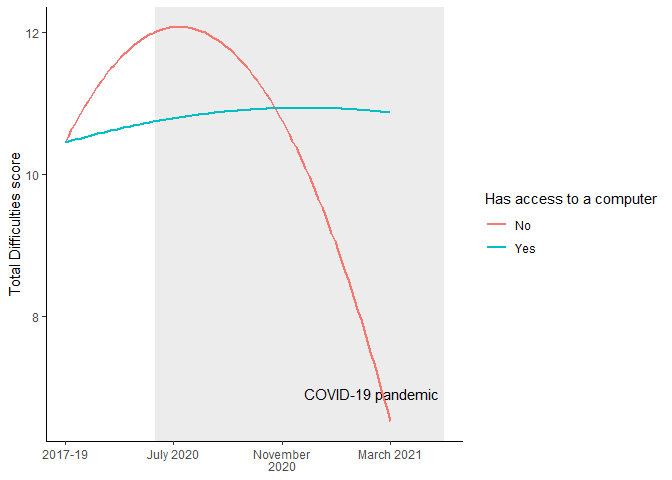

### Final LGM (weighted, not reliable, by group with predicted individual trajectories)

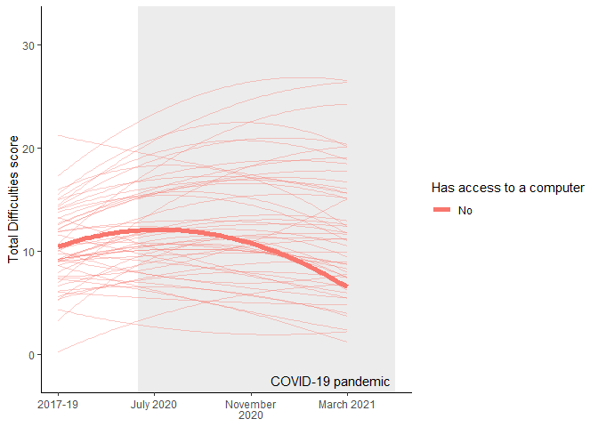

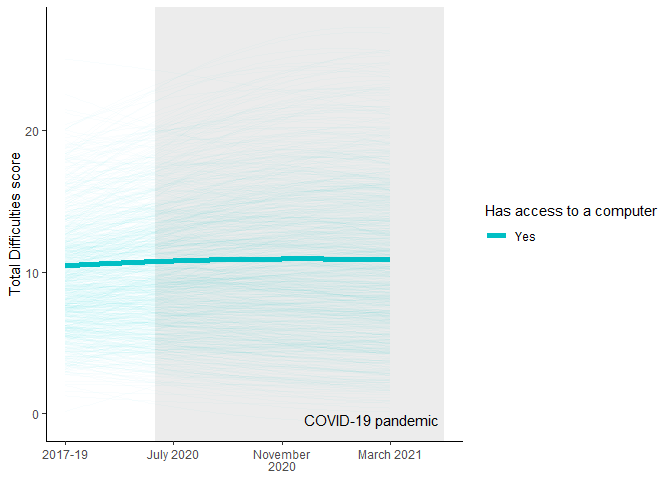

# Fitting models grouped by internet access with covariates

We now fit a new LGM with the participants grouped by whether or not they have access to a “good internet connection”, and controlling for sex, birth year, ethnicity and mean household income.

```r
# Fitting no-change model
model_int_nc <- '
sex_merged ~ 1; sex_merged ~~ sex_merged
birthy ~ 1; birthy ~~ birthy
ethn_caucasian ~ 1; ethn_caucasian ~~ ethn_caucasian
mean_income ~ 1; mean_income ~~ mean_income

i =~ 1*W9 + 1*CV4 + 1*CV6 + 1*CV8

i ~ sex_merged + birthy + ethn_caucasian + mean_income
'

fit_int_nc <- growth(model_int_nc, data = data_sdq[!is.na(data_sdq$ypschlth2),], group = "ypschlth2", missing = "fiml", estimator = "mlr")
# Fitting linear model
model_int_lin <- '
sex_merged ~ 1; sex_merged ~~ sex_merged
birthy ~ 1; birthy ~~ birthy
ethn_caucasian ~ 1; ethn_caucasian ~~ ethn_caucasian
mean_income ~ 1; mean_income ~~ mean_income

i =~ 1*W9 + 1*CV4 + 1*CV6 + 1*CV8
s =~ 0*W9 + 1*CV4 + 2*CV6 + 3*CV8

i ~ sex_merged + birthy + ethn_caucasian + mean_income
s ~ sex_merged + birthy + ethn_caucasian + mean_income
'

fit_int_lin <- growth(model_int_lin, data = data_sdq[!is.na(data_sdq$ypschlth2),], group = "ypschlth2", missing = "fiml", estimator = "mlr")
# Comparing linear to no-change model
anova(fit_int_lin, fit_int_nc)
```

```
## Scaled Chi-Squared Difference Test (method = "satorra.bentler.2001")
##
## lavaan NOTE:
##     The "Chisq" column contains standard test statistics, not the
##     robust test that should be reported per model. A robust difference
##     test is a function of two standard (not robust) statistics.
##
##             Df   AIC   BIC   Chisq Chisq diff Df diff Pr(>Chisq)
## fit_int_lin 38 17672 17908  78.606
## fit_int_nc  52 17771 17941 205.744     125.18      14  < 2.2e-16 ***
## ---
## Signif. codes:  0 '***' 0.001 '**' 0.01 '*' 0.05 '.' 0.1 ' ' 1
```

```r
# Accepting linear over no-change model

# Fitting quadratic model
model_int_quad <- '
sex_merged ~ 1; sex_merged ~~ sex_merged
birthy ~ 1; birthy ~~ birthy
ethn_caucasian ~ 1; ethn_caucasian ~~ ethn_caucasian
mean_income ~ 1; mean_income ~~ mean_income

i =~ 1*W9 + 1*CV4 + 1*CV6 + 1*CV8
s =~ 0*W9 + 1*CV4 + 2*CV6 + 3*CV8
q =~ 0*W9 + 1*CV4 + 4*CV6 + 9*CV8

i ~ sex_merged + birthy + ethn_caucasian + mean_income
s ~ sex_merged + birthy + ethn_caucasian + mean_income
q ~ sex_merged + birthy + ethn_caucasian + mean_income
'

fit_int_quad <- growth(model_int_quad, data = data_sdq[!is.na(data_sdq$ypschlth2),], group = "ypschlth2", missing = "fiml", estimator = "mlr")
# Comparing quadratic to linear model
anova(fit_int_quad, fit_int_lin)
```

```
## Scaled Chi-Squared Difference Test (method = "satorra.bentler.2001")
##
## lavaan NOTE:
##     The "Chisq" column contains standard test statistics, not the
##     robust test that should be reported per model. A robust difference
##     test is a function of two standard (not robust) statistics.
##
##              Df   AIC   BIC  Chisq Chisq diff Df diff Pr(>Chisq)
## fit_int_quad 22 17652 17964 26.719
## fit_int_lin  38 17672 17908 78.606     47.292      16  6.132e-05 ***
## ---
## Signif. codes:  0 '***' 0.001 '**' 0.01 '*' 0.05 '.' 0.1 ' ' 1
```

```r
# Accepting quadratic over linear model

# Fitting model with error variances constrained to equality
model_int_con_ervar <- '
sex_merged ~ 1; sex_merged ~~ sex_merged
birthy ~ 1; birthy ~~ birthy
ethn_caucasian ~ 1; ethn_caucasian ~~ ethn_caucasian
mean_income ~ 1; mean_income ~~ mean_income

i =~ 1*W9 + 1*CV4 + 1*CV6 + 1*CV8
s =~ 0*W9 + 1*CV4 + 2*CV6 + 3*CV8
q =~ 0*W9 + 1*CV4 + 4*CV6 + 9*CV8

W9 ~~ c(ervar1, ervar1) * W9
CV4 ~~ c(ervar2, ervar2) * CV4
CV6 ~~ c(ervar3, ervar3) * CV6
CV8 ~~ c(ervar4, ervar4) * CV8

i ~ sex_merged + birthy + ethn_caucasian + mean_income
s ~ sex_merged + birthy + ethn_caucasian + mean_income
q ~ sex_merged + birthy + ethn_caucasian + mean_income
'

fit_int_con_ervar <- growth(model_int_con_ervar, data = data_sdq[!is.na(data_sdq$ypschlth2),], group = "ypschlth2", missing = "fiml", estimator = "mlr")
# Comparing model with constrained error variances to free model
anova(fit_int_con_ervar, fit_int_quad)
```

```
## Scaled Chi-Squared Difference Test (method = "satorra.bentler.2001")
##
## lavaan NOTE:
##     The "Chisq" column contains standard test statistics, not the
##     robust test that should be reported per model. A robust difference
##     test is a function of two standard (not robust) statistics.
##
##                   Df   AIC   BIC  Chisq Chisq diff Df diff Pr(>Chisq)
## fit_int_quad      22 17652 17964 26.719
## fit_int_con_ervar 26 17647 17940 29.834     2.4817       4     0.6479
```

```r
# Accepting model with constrained error variances over free model

# Fitting model with constrained y-intercept
model_int_con_i <- '
sex_merged ~ 1; sex_merged ~~ sex_merged
birthy ~ 1; birthy ~~ birthy
ethn_caucasian ~ 1; ethn_caucasian ~~ ethn_caucasian
mean_income ~ 1; mean_income ~~ mean_income

i =~ 1*W9 + 1*CV4 + 1*CV6 + 1*CV8
s =~ 0*W9 + 1*CV4 + 2*CV6 + 3*CV8
q =~ 0*W9 + 1*CV4 + 4*CV6 + 9*CV8

W9 ~~ c(ervar1, ervar1) * W9
CV4 ~~ c(ervar2, ervar2) * CV4
CV6 ~~ c(ervar3, ervar3) * CV6
CV8 ~~ c(ervar4, ervar4) * CV8

i ~ c(i_1, i_1) * 1

i ~ sex_merged + birthy + ethn_caucasian + mean_income
s ~ sex_merged + birthy + ethn_caucasian + mean_income
q ~ sex_merged + birthy + ethn_caucasian + mean_income
'

fit_int_con_i <- growth(model_int_con_i, data = data_sdq[!is.na(data_sdq$ypschlth2),], group = "ypschlth2", missing = "fiml", estimator = "mlr")
# Comparing model with constrained y-intercept to model without
anova(fit_int_con_i, fit_int_con_ervar)
```

```
## Scaled Chi-Squared Difference Test (method = "satorra.bentler.2001")
##
## lavaan NOTE:
##     The "Chisq" column contains standard test statistics, not the
##     robust test that should be reported per model. A robust difference
##     test is a function of two standard (not robust) statistics.
##
##                   Df   AIC   BIC  Chisq Chisq diff Df diff Pr(>Chisq)
## fit_int_con_ervar 26 17647 17940 29.834
## fit_int_con_i     27 17646 17934 30.797     1.2482       1     0.2639
```

```r
# Accepting model with constrained y-intercept over model without

# Fitting model with constrained linear coefficient
model_int_con_i_s <- '
sex_merged ~ 1; sex_merged ~~ sex_merged
birthy ~ 1; birthy ~~ birthy
ethn_caucasian ~ 1; ethn_caucasian ~~ ethn_caucasian
mean_income ~ 1; mean_income ~~ mean_income

i =~ 1*W9 + 1*CV4 + 1*CV6 + 1*CV8
s =~ 0*W9 + 1*CV4 + 2*CV6 + 3*CV8
q =~ 0*W9 + 1*CV4 + 4*CV6 + 9*CV8

W9 ~~ c(ervar1, ervar1) * W9
CV4 ~~ c(ervar2, ervar2) * CV4
CV6 ~~ c(ervar3, ervar3) * CV6
CV8 ~~ c(ervar4, ervar4) * CV8

i ~ c(i_1, i_1) * 1
s ~ c(s_1, s_1) * 1

i ~ sex_merged + birthy + ethn_caucasian + mean_income
s ~ sex_merged + birthy + ethn_caucasian + mean_income
q ~ sex_merged + birthy + ethn_caucasian + mean_income
'

fit_int_con_i_s <- growth(model_int_con_i_s, data = data_sdq[!is.na(data_sdq$ypschlth2),], group = "ypschlth2", missing = "fiml", estimator = "mlr")
# Comparing model with constrained linear coefficient to model without
anova(fit_int_con_i_s, fit_int_con_i)
```

```
## Scaled Chi-Squared Difference Test (method = "satorra.bentler.2001")
##
## lavaan NOTE:
##     The "Chisq" column contains standard test statistics, not the
##     robust test that should be reported per model. A robust difference
##     test is a function of two standard (not robust) statistics.
##
##                 Df   AIC   BIC  Chisq Chisq diff Df diff Pr(>Chisq)
## fit_int_con_i   27 17646 17934 30.797
## fit_int_con_i_s 28 17645 17929 31.729    0.96442       1     0.3261
```

```r
# Accepting model with constrained linear coefficient over model without

# Fitting model with constrained quadratic coefficient
model_int_con_i_s_q <- '
sex_merged ~ 1; sex_merged ~~ sex_merged
birthy ~ 1; birthy ~~ birthy
ethn_caucasian ~ 1; ethn_caucasian ~~ ethn_caucasian
mean_income ~ 1; mean_income ~~ mean_income

i =~ 1*W9 + 1*CV4 + 1*CV6 + 1*CV8
s =~ 0*W9 + 1*CV4 + 2*CV6 + 3*CV8
q =~ 0*W9 + 1*CV4 + 4*CV6 + 9*CV8

W9 ~~ c(ervar1, ervar1) * W9
CV4 ~~ c(ervar2, ervar2) * CV4
CV6 ~~ c(ervar3, ervar3) * CV6
CV8 ~~ c(ervar4, ervar4) * CV8

i ~ c(i_1, i_1) * 1
s ~ c(s_1, s_1) * 1
q ~ c(q_1, q_1) * 1

i ~ sex_merged + birthy + ethn_caucasian + mean_income
s ~ sex_merged + birthy + ethn_caucasian + mean_income
q ~ sex_merged + birthy + ethn_caucasian + mean_income
'

fit_int_con_i_s_q <- growth(model_int_con_i_s_q, data = data_sdq[!is.na(data_sdq$ypschlth2),], group = "ypschlth2", missing = "fiml", estimator = "mlr")
# Comparing model with constrained quadratic coefficient to model without
anova(fit_int_con_i_s_q, fit_int_con_i_s)
```

```
## Scaled Chi-Squared Difference Test (method = "satorra.bentler.2001")
##
## lavaan NOTE:
##     The "Chisq" column contains standard test statistics, not the
##     robust test that should be reported per model. A robust difference
##     test is a function of two standard (not robust) statistics.
##
##                   Df   AIC   BIC  Chisq Chisq diff Df diff Pr(>Chisq)
## fit_int_con_i_s   28 17645 17929 31.729
## fit_int_con_i_s_q 29 17644 17923 32.624    0.53067       1     0.4663
```

```r
# Accepting model with constrained quadratic coefficient over model without
fit_int_prov <- fit_int_con_i_s_q

# Fitting model with constrained y-intercept variance
model_int_con_ivar <- '
sex_merged ~ 1; sex_merged ~~ sex_merged
birthy ~ 1; birthy ~~ birthy
ethn_caucasian ~ 1; ethn_caucasian ~~ ethn_caucasian
mean_income ~ 1; mean_income ~~ mean_income

i =~ 1*W9 + 1*CV4 + 1*CV6 + 1*CV8
s =~ 0*W9 + 1*CV4 + 2*CV6 + 3*CV8
q =~ 0*W9 + 1*CV4 + 4*CV6 + 9*CV8

W9 ~~ c(ervar1, ervar1) * W9
CV4 ~~ c(ervar2, ervar2) * CV4
CV6 ~~ c(ervar3, ervar3) * CV6
CV8 ~~ c(ervar4, ervar4) * CV8

i ~ c(i_1, i_1) * 1
s ~ c(s_1, s_1) * 1
q ~ c(q_1, q_1) * 1

i ~~ c(ivar, ivar) * i

i ~ sex_merged + birthy + ethn_caucasian + mean_income
s ~ sex_merged + birthy + ethn_caucasian + mean_income
q ~ sex_merged + birthy + ethn_caucasian + mean_income
'

fit_int_con_ivar <- growth(model_int_con_ivar, data = data_sdq[!is.na(data_sdq$ypschlth2),], group = "ypschlth2", missing = "fiml", estimator = "mlr")
# Comparing model with constrained y-intercept variance to model without
anova(fit_int_con_ivar, fit_int_prov)
```

```
## Scaled Chi-Squared Difference Test (method = "satorra.bentler.2001")
##
## lavaan NOTE:
##     The "Chisq" column contains standard test statistics, not the
##     robust test that should be reported per model. A robust difference
##     test is a function of two standard (not robust) statistics.
##
##                  Df   AIC   BIC  Chisq Chisq diff Df diff Pr(>Chisq)
## fit_int_prov     29 17644 17923 32.624
## fit_int_con_ivar 30 17642 17917 33.152    0.36071       1     0.5481
```

```r
# Accepting model with constrained y-intercept variance over model without

# Fitting model with constrained linear coefficient variance
model_int_con_ivar_svar <- '
sex_merged ~ 1; sex_merged ~~ sex_merged
birthy ~ 1; birthy ~~ birthy
ethn_caucasian ~ 1; ethn_caucasian ~~ ethn_caucasian
mean_income ~ 1; mean_income ~~ mean_income

i =~ 1*W9 + 1*CV4 + 1*CV6 + 1*CV8
s =~ 0*W9 + 1*CV4 + 2*CV6 + 3*CV8
q =~ 0*W9 + 1*CV4 + 4*CV6 + 9*CV8

W9 ~~ c(ervar1, ervar1) * W9
CV4 ~~ c(ervar2, ervar2) * CV4
CV6 ~~ c(ervar3, ervar3) * CV6
CV8 ~~ c(ervar4, ervar4) * CV8

i ~ c(i_1, i_1) * 1
s ~ c(s_1, s_1) * 1
q ~ c(q_1, q_1) * 1

i ~~ c(ivar, ivar) * i
s ~~ c(svar, svar) * s

i ~ sex_merged + birthy + ethn_caucasian + mean_income
s ~ sex_merged + birthy + ethn_caucasian + mean_income
q ~ sex_merged + birthy + ethn_caucasian + mean_income
'

fit_int_con_ivar_svar <- growth(model_int_con_ivar_svar, data = data_sdq[!is.na(data_sdq$ypschlth2),], group = "ypschlth2", missing = "fiml", estimator = "mlr")
# Comparing model with constrained linear coefficient variance to model without
anova(fit_int_con_ivar_svar, fit_int_con_ivar)
```

```
## Scaled Chi-Squared Difference Test (method = "satorra.bentler.2001")
##
## lavaan NOTE:
##     The "Chisq" column contains standard test statistics, not the
##     robust test that should be reported per model. A robust difference
##     test is a function of two standard (not robust) statistics.
##
##                       Df   AIC   BIC  Chisq Chisq diff Df diff Pr(>Chisq)
## fit_int_con_ivar      30 17642 17917 33.152
## fit_int_con_ivar_svar 31 17640 17910 33.301   0.080244       1      0.777
```

```r
# Accepting model with constrained linear coefficient variance over model without

# Fitting model with constrained quadratic coefficient variance
model_int_con_ivar_svar_qvar <- '
sex_merged ~ 1; sex_merged ~~ sex_merged
birthy ~ 1; birthy ~~ birthy
ethn_caucasian ~ 1; ethn_caucasian ~~ ethn_caucasian
mean_income ~ 1; mean_income ~~ mean_income

i =~ 1*W9 + 1*CV4 + 1*CV6 + 1*CV8
s =~ 0*W9 + 1*CV4 + 2*CV6 + 3*CV8
q =~ 0*W9 + 1*CV4 + 4*CV6 + 9*CV8

W9 ~~ c(ervar1, ervar1) * W9
CV4 ~~ c(ervar2, ervar2) * CV4
CV6 ~~ c(ervar3, ervar3) * CV6
CV8 ~~ c(ervar4, ervar4) * CV8

i ~ c(i_1, i_1) * 1
s ~ c(s_1, s_1) * 1
q ~ c(q_1, q_1) * 1

i ~~ c(ivar, ivar) * i
s ~~ c(svar, svar) * s
q ~~ c(qvar, qvar) * q

i ~ sex_merged + birthy + ethn_caucasian + mean_income
s ~ sex_merged + birthy + ethn_caucasian + mean_income
q ~ sex_merged + birthy + ethn_caucasian + mean_income
'

fit_int_con_ivar_svar_qvar <- growth(model_int_con_ivar_svar_qvar, data = data_sdq[!is.na(data_sdq$ypschlth2),], group = "ypschlth2", missing = "fiml", estimator = "mlr")
# Comparing model with constrained quadratic coefficient variance to model without
anova(fit_int_con_ivar_svar_qvar, fit_int_con_ivar_svar)
```

```
## Scaled Chi-Squared Difference Test (method = "satorra.bentler.2001")
##
## lavaan NOTE:
##     The "Chisq" column contains standard test statistics, not the
##     robust test that should be reported per model. A robust difference
##     test is a function of two standard (not robust) statistics.
##
##                            Df   AIC   BIC  Chisq Chisq diff Df diff Pr(>Chisq)
## fit_int_con_ivar_svar      31 17640 17910 33.301
## fit_int_con_ivar_svar_qvar 32 17642 17907 36.730     3.4846       1    0.06194
##
## fit_int_con_ivar_svar
## fit_int_con_ivar_svar_qvar .
## ---
## Signif. codes:  0 '***' 0.001 '**' 0.01 '*' 0.05 '.' 0.1 ' ' 1
```

```r
# Accepting model with constrained quadratic coefficient variance over model without
fit_int_prov <- fit_int_con_ivar_svar_qvar

# Fitting model with constrained y-intercept/linear coefficient covariance
model_int_con_iscovar <- '
sex_merged ~ 1; sex_merged ~~ sex_merged
birthy ~ 1; birthy ~~ birthy
ethn_caucasian ~ 1; ethn_caucasian ~~ ethn_caucasian
mean_income ~ 1; mean_income ~~ mean_income

i =~ 1*W9 + 1*CV4 + 1*CV6 + 1*CV8
s =~ 0*W9 + 1*CV4 + 2*CV6 + 3*CV8
q =~ 0*W9 + 1*CV4 + 4*CV6 + 9*CV8

W9 ~~ c(ervar1, ervar1) * W9
CV4 ~~ c(ervar2, ervar2) * CV4
CV6 ~~ c(ervar3, ervar3) * CV6
CV8 ~~ c(ervar4, ervar4) * CV8

i ~ c(i_1, i_1) * 1
s ~ c(s_1, s_1) * 1
q ~ c(q_1, q_1) * 1

i ~~ c(ivar, ivar) * i
s ~~ c(svar, svar) * s
q ~~ c(qvar, qvar) * q

i ~~ c(iscovar, iscovar) * s

i ~ sex_merged + birthy + ethn_caucasian + mean_income
s ~ sex_merged + birthy + ethn_caucasian + mean_income
q ~ sex_merged + birthy + ethn_caucasian + mean_income
'

fit_int_con_iscovar <- growth(model_int_con_iscovar, data = data_sdq[!is.na(data_sdq$ypschlth2),], group = "ypschlth2", missing = "fiml", estimator = "mlr")
# Comparing model with constrained y-intercept/linear coefficient covariance to model without
anova(fit_int_con_iscovar, fit_int_prov)
```

```
## Scaled Chi-Squared Difference Test (method = "satorra.bentler.2001")
##
## lavaan NOTE:
##     The "Chisq" column contains standard test statistics, not the
##     robust test that should be reported per model. A robust difference
##     test is a function of two standard (not robust) statistics.
##
##                     Df   AIC   BIC Chisq Chisq diff Df diff Pr(>Chisq)
## fit_int_prov        32 17642 17907 36.73
## fit_int_con_iscovar 33 17640 17900 36.73 0.00031216       1     0.9859
```

```r
# Accepting model with constrained y-intercept/linear coefficient covariance over model without

# Fitting model with constrained y-intercept/quadratic coefficient covariance
model_int_con_iscovar_iqcovar <- '
sex_merged ~ 1; sex_merged ~~ sex_merged
birthy ~ 1; birthy ~~ birthy
ethn_caucasian ~ 1; ethn_caucasian ~~ ethn_caucasian
mean_income ~ 1; mean_income ~~ mean_income

i =~ 1*W9 + 1*CV4 + 1*CV6 + 1*CV8
s =~ 0*W9 + 1*CV4 + 2*CV6 + 3*CV8
q =~ 0*W9 + 1*CV4 + 4*CV6 + 9*CV8

W9 ~~ c(ervar1, ervar1) * W9
CV4 ~~ c(ervar2, ervar2) * CV4
CV6 ~~ c(ervar3, ervar3) * CV6
CV8 ~~ c(ervar4, ervar4) * CV8

i ~ c(i_1, i_1) * 1
s ~ c(s_1, s_1) * 1
q ~ c(q_1, q_1) * 1

i ~~ c(ivar, ivar) * i
s ~~ c(svar, svar) * s
q ~~ c(qvar, qvar) * q

i ~~ c(iscovar, iscovar) * s
i ~~ c(iqcovar, iqcovar) * q

i ~ sex_merged + birthy + ethn_caucasian + mean_income
s ~ sex_merged + birthy + ethn_caucasian + mean_income
q ~ sex_merged + birthy + ethn_caucasian + mean_income
'

fit_int_con_iscovar_iqcovar <- growth(model_int_con_iscovar_iqcovar, data = data_sdq[!is.na(data_sdq$ypschlth2),], group = "ypschlth2", missing = "fiml", estimator = "mlr")
# Comparing model with constrained y-intercept/quadratic coefficient covariance to model without
anova(fit_int_con_iscovar_iqcovar, fit_int_con_iscovar)
```

```
## Scaled Chi-Squared Difference Test (method = "satorra.bentler.2001")
##
## lavaan NOTE:
##     The "Chisq" column contains standard test statistics, not the
##     robust test that should be reported per model. A robust difference
##     test is a function of two standard (not robust) statistics.
##
##                             Df   AIC   BIC  Chisq Chisq diff Df diff Pr(>Chisq)
## fit_int_con_iscovar         33 17640 17900 36.730
## fit_int_con_iscovar_iqcovar 34 17646 17902 45.332     5.9679       1    0.01457
##
## fit_int_con_iscovar
## fit_int_con_iscovar_iqcovar *
## ---
## Signif. codes:  0 '***' 0.001 '**' 0.01 '*' 0.05 '.' 0.1 ' ' 1
```

```r
# Rejecting model with constrained y-intercept/quadratic coefficient covariance

# Fitting model with constrained linear coefficient/quadratic coefficient covariance
model_int_con_iscovar_sqcovar <- '
sex_merged ~ 1; sex_merged ~~ sex_merged
birthy ~ 1; birthy ~~ birthy
ethn_caucasian ~ 1; ethn_caucasian ~~ ethn_caucasian
mean_income ~ 1; mean_income ~~ mean_income

i =~ 1*W9 + 1*CV4 + 1*CV6 + 1*CV8
s =~ 0*W9 + 1*CV4 + 2*CV6 + 3*CV8
q =~ 0*W9 + 1*CV4 + 4*CV6 + 9*CV8

W9 ~~ c(ervar1, ervar1) * W9
CV4 ~~ c(ervar2, ervar2) * CV4
CV6 ~~ c(ervar3, ervar3) * CV6
CV8 ~~ c(ervar4, ervar4) * CV8

i ~ c(i_1, i_1) * 1
s ~ c(s_1, s_1) * 1
q ~ c(q_1, q_1) * 1

i ~~ c(ivar, ivar) * i
s ~~ c(svar, svar) * s
q ~~ c(qvar, qvar) * q

i ~~ c(iscovar, iscovar) * s
s ~~ c(sqcovar, sqcovar) * q

i ~ sex_merged + birthy + ethn_caucasian + mean_income
s ~ sex_merged + birthy + ethn_caucasian + mean_income
q ~ sex_merged + birthy + ethn_caucasian + mean_income
'

fit_int_con_iscovar_sqcovar <- growth(model_int_con_iscovar_sqcovar, data = data_sdq[!is.na(data_sdq$ypschlth2),], group = "ypschlth2", missing = "fiml", estimator = "mlr")
# Comparing model with constrained linear coefficient/quadratic coefficient covariance to model without
anova(fit_int_con_iscovar_sqcovar, fit_int_con_iscovar)
```

```
## Scaled Chi-Squared Difference Test (method = "satorra.bentler.2001")
##
## lavaan NOTE:
##     The "Chisq" column contains standard test statistics, not the
##     robust test that should be reported per model. A robust difference
##     test is a function of two standard (not robust) statistics.
##
##                             Df   AIC   BIC  Chisq Chisq diff Df diff Pr(>Chisq)
## fit_int_con_iscovar         33 17640 17900 36.730
## fit_int_con_iscovar_sqcovar 34 17641 17897 40.291     1.5358       1     0.2152
```

```r
# Accepting model with constrained linear coefficient/quadratic coefficient covariance over model without
fit_int <- fit_int_con_iscovar_sqcovar

# Summary of unweighted model
summary(fit_int)
```

```
## lavaan 0.6-9 ended normally after 345 iterations
##
##   Estimator                                         ML
##   Optimization method                           NLMINB
##   Number of model parameters                        66
##   Number of equality constraints                    12
##
##   Number of observations per group:
##     1                                              746
##     0                                               90
##   Number of missing patterns per group:
##     1                                               13
##     0                                                7
##
## Model Test User Model:
##                                                Standard      Robust
##   Test Statistic                                 40.291      37.277
##   Degrees of freedom                                 34          34
##   P-value (Chi-square)                            0.212       0.321
##   Scaling correction factor                                   1.081
##        Yuan-Bentler correction (Mplus variant)
##   Test statistic for each group:
##     1                                           12.083      11.179
##     0                                           28.208      26.098
##
## Parameter Estimates:
##
##   Standard errors                             Sandwich
##   Information bread                           Observed
##   Observed information based on                Hessian
##
##
## Group 1 [1]:
##
## Latent Variables:
##                    Estimate  Std.Err  z-value  P(>|z|)
##   i =~
##     W9                1.000
##     CV4               1.000
##     CV6               1.000
```

[output cut: 127 more lines]

```
##    .CV8               0.000
##
## Variances:
##                    Estimate  Std.Err  z-value  P(>|z|)
##     sx_mrgd           0.232    0.014   17.144    0.000
##     birthy            0.057    0.006    9.004    0.000
##     ethn_cc           0.218    0.018   12.469    0.000
##     men_ncm           0.016    0.007    2.194    0.028
##    .W9      (erv1)   10.081    4.115    2.450    0.014
##    .CV4     (erv2)   10.117    1.340    7.551    0.000
##    .CV6     (erv3)    8.468    1.339    6.326    0.000
##    .CV8     (erv4)    5.198    3.799    1.368    0.171
##    .i       (ivar)   20.514    4.483    4.576    0.000
##    .s       (svar)    7.472    5.451    1.371    0.171
##    .q       (qvar)    0.282    0.368    0.767    0.443
```

```r
# Saving model fit object
saveRDS(fit_int, file = "Data/Objects/int_cov.rds")

# Preparing LGM functions for plotting
pT <- parTable(fit_int)
fit_int_fn0 <- function(x) pT[pT$lhs == "i" & pT$op == "~1" & pT$group == 2,]$est + pT[pT$lhs == "s" & pT$op == "~1" & pT$group == 2,]$est*x + pT[pT$lhs == "q" & pT$op == "~1" & pT$group == 2,]$est*x^2
fit_int_fn1 <- function(x) pT[pT$lhs == "i" & pT$op == "~1" & pT$group == 1,]$est + pT[pT$lhs == "s" & pT$op == "~1" & pT$group == 1,]$est*x + pT[pT$lhs == "q" & pT$op == "~1" & pT$group == 1,]$est*x^2

# Using LGM parameters to predict individual trajectories
indiv_traj_p <- predict(fit_int)

# Saving predicted trajectories object
saveRDS(indiv_traj_p, file = "Data/Objects/int_predict.rds")

# Extracting predicted individual trajectory data
indiv_traj0 <- data.frame(indiv_traj_p[["0"]])
indiv_traj1 <- data.frame(indiv_traj_p[["1"]])
i <- nrow(indiv_traj0)
j <- nrow(indiv_traj1)
```

### Final LGM (unweighted)

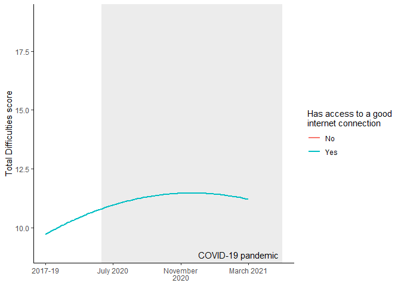

### Final LGM (unweighted, by group with individual trajectories)

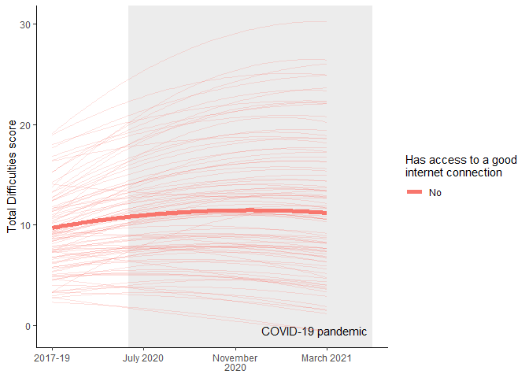

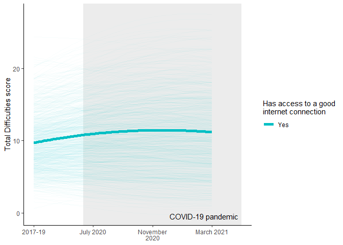

```r
# Applying weights to model
fit_int_weighted <- lavaan.survey(fit_int_con_iscovar_sqcovar, survey_design, estimator = "ML")
# Summary of weighted model
summary(fit_int_weighted)
```

```
## lavaan 0.6-9 ended normally after 373 iterations
##
##   Estimator                                         ML
##   Optimization method                           NLMINB
##   Number of model parameters                        66
##   Number of equality constraints                    12
##
##   Number of observations per group:
##     Group 1                                        746
##     Group 2                                         90
##
## Model Test User Model:
##
##   Test statistic                               155.705
##   Degrees of freedom                                34
##   P-value (Chi-square)                           0.000
##   Test statistic for each group:
##     Group 1                                     55.494
##     Group 2                                    100.211
##
## Parameter Estimates:
##
##   Standard errors                             Standard
##   Information                                 Observed
##   Observed information based on                Hessian
##
##
## Group 1 [Group 1]:
##
## Latent Variables:
##                    Estimate  Std.Err  z-value  P(>|z|)
##   i =~
##     W9                1.000
##     CV4               1.000
##     CV6               1.000
##     CV8               1.000
##   s =~
##     W9                0.000
##     CV4               1.000
##     CV6               2.000
```

[output cut: 122 more lines]

```
##    .CV8               0.000
##
## Variances:
##                    Estimate  Std.Err  z-value  P(>|z|)
##     sx_mrgd           0.242    0.036    6.708    0.000
##     birthy            0.023    0.003    6.708    0.000
##     ethn_cc           0.233    0.035    6.708    0.000
##     men_ncm           0.011    0.002    6.708    0.000
##    .W9      (erv1)    8.269    2.374    3.482    0.000
##    .CV4     (erv2)    7.773    0.815    9.541    0.000
##    .CV6     (erv3)    7.287    0.846    8.614    0.000
##    .CV8     (erv4)    5.890    2.426    2.427    0.015
##    .i       (ivar)   20.982    2.546    8.241    0.000
##    .s       (svar)    7.031    2.848    2.469    0.014
##    .q       (qvar)    0.242    0.187    1.295    0.195
```

```r
# Preparing LGM functions for plotting
pT <- parTable(fit_int_weighted)
fit_int_fn0 <- function(x) pT[pT$lhs == "i" & pT$op == "~1" & pT$group == 2,]$est + pT[pT$lhs == "s" & pT$op == "~1" & pT$group == 2,]$est*x + pT[pT$lhs == "q" & pT$op == "~1" & pT$group == 2,]$est*x^2
fit_int_fn1 <- function(x) pT[pT$lhs == "i" & pT$op == "~1" & pT$group == 1,]$est + pT[pT$lhs == "s" & pT$op == "~1" & pT$group == 1,]$est*x + pT[pT$lhs == "q" & pT$op == "~1" & pT$group == 1,]$est*x^2
```

### Final LGM (weighted)

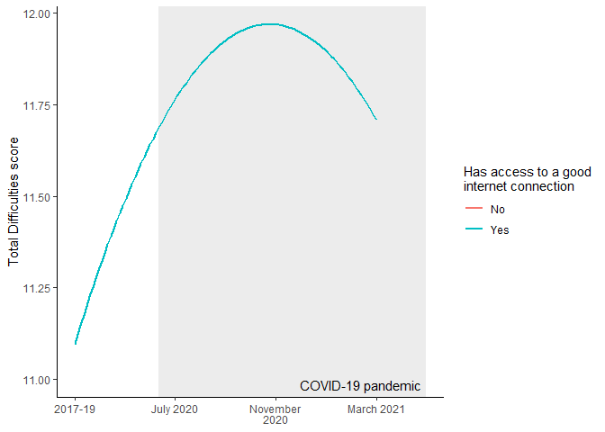

### Final LGM (weighted, by group with predicted individual trajectories)

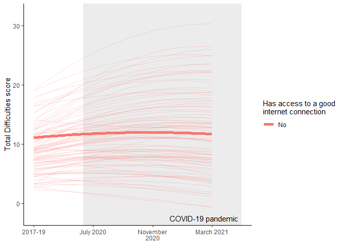

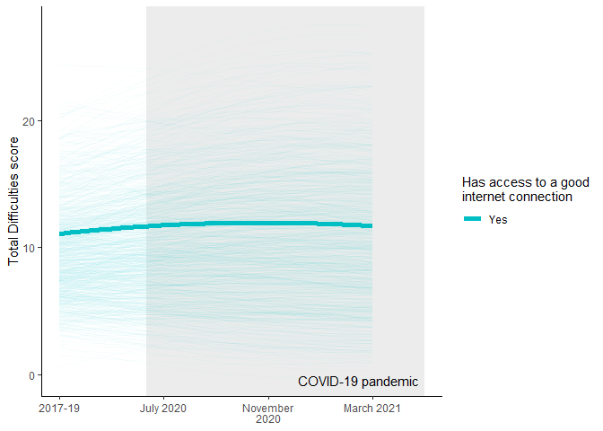